# TD 9 : Normalisation FN3 et FNBC

Décomposition SPD, SPI, FN3 et FNBC

Normalisation

Décomposition

Perte de DF

Perte d'information

SPD

SPI

FN3

FNBC

Published

| L3 MIASHS |
| --- |
| [Université Paris Cité](https://www.u-paris.fr) |
| Année 2025 |
| [Course Homepage](https://bgentou.github.io/MA15E045/) |
| [Moodle](https://moodle.u-paris.fr/course/view.php?id=2313) |

## Exercice 1

L’étude d’un SI a conduit à ce diagramme des DF

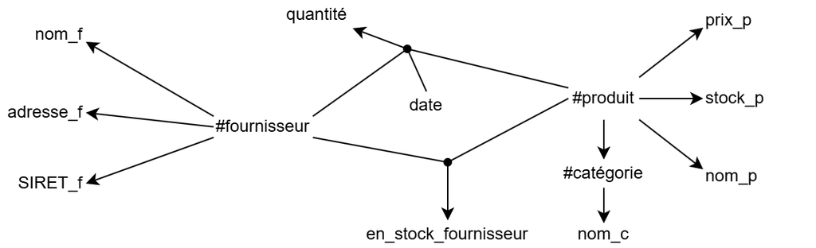

L’équipe de conception vous a fourni ce modèle conceptuel

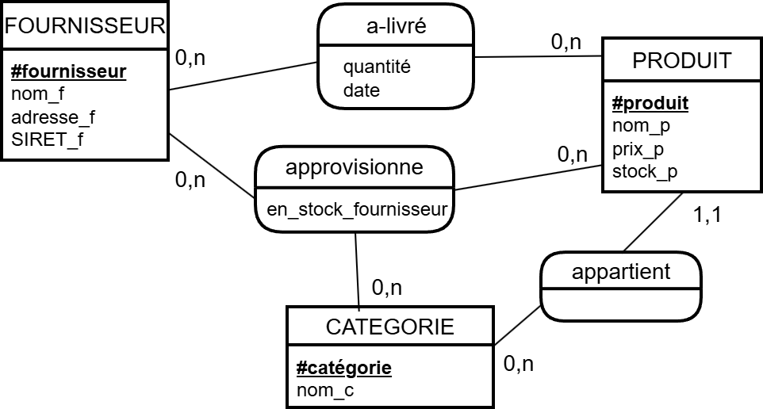

La traduction relationnelle donne ce schéma relationnel :

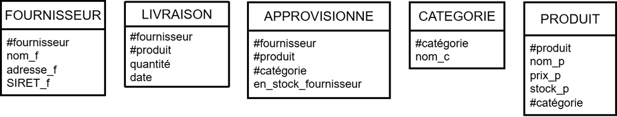

**NoteQuestion**

Déterminer si ce schéma relationnel entraine des pertes de DF ?

**NoteQuestion**

Pour chaque relation de ce schéma, déterminer les clés et vérifier si elle est en FNBC, sinon donner la forme normale optimale qu’elle vérifie.

**NoteQuestion**

Pour les tables qui ne sont pas FNBC, illustrer les redondances par des exemples de tuples.

**NoteQuestion**

En reprenant la conception du schéma, proposer un modèle E/A qui représente correctement les DF et le traduire en un modèle relationnel FNBC.

## Exercice 2

On reprend un schéma $\mathcal{A}$ déjà étudié dans le TD précédent.

$\mathcal{A}$={Occupant, Adresse, Noapt, Nbpersonnes, Nbpièces, Propriétaire}.

Un tuple `(o, a, n, np, nr, p)` a la signification suivante : la personne `o` habite à l’adresse `a` l’appartement de numéro `n` avec `np` personnes ayant `nr` pièces dont le propriétaire est `p`.

$\mathcal{A}$ vérifie l’ensemble $\Sigma$ des dépendances fonctionnelles suivantes

```
Occupant → Adresse
Occupant → Noapt
Occupant → Nbpersonnes
Adresse → Propriétaire
Adresse, Noapt → Occupant
Adresse, Noapt → Nbpièces
```

On considère les décompositions suivantes:

- **Décomposition 1** :
  - $\mathcal{A_1}$ = {Occupant, Adresse, Nbpersonnes, Propriétaire},
  - $\mathcal{A_2}$ = {Adresse, Noapt, Occupant, Nbpièces}.
- **Décomposition 2** :
  - $\mathcal{A_1}$ = {Occupant, Nbpersonnes},
  - $\mathcal{A_2}$ = {Adresse, Noapt, Occupant, Nbpièces},
  - $\mathcal{A_3}$ = {Adresse, Propriétaire}.

**NoteQuestion**

Montrer que $\Sigma$ est irredondante.

**NoteQuestion**

Montrer que ces décompositions sont sans pertes de DF.

**NoteQuestion**

En utilisant l’algorithme de poursuite, déterminer si ces décompositions sont sans pertes d’information.

**NoteQuestion**

Déterminer la FN optimale que vérifie chacune des décompositions.

**NoteQuestion**

Appliquer l’algorithme de décomposition FN3 vu en cours pour obtenir une décomposition de $\mathcal{A}$ sans pertes de DF et sans pertes d’informations.

La décomposition obtenue est-elle FNBC ?

Comparer avec les décompositions précédentes.

**WarningRetenir**

Les normalisations FN2, FN3 et FNBC ne réduisent que les redondances internes à chaque table liées à l’existence de DF entre les attributs.

**NoteQuestion**

Appliquer l’algorithme de décomposition FNBC vu en cours pour obtenir une décomposition FNBC de $\mathcal{A}$ sans pertes d’information. La décomposition préserve-t-elle toutes les DF ?

Comparer avec les décompositions précédentes.

## Exercice 3

Soit le schéma $\mathcal{A}$={A,B,C,D,E,F,G,H} et l’ensemble $\Sigma$ de DF
$$BE → AC  \quad
B → H  \quad
F → CD  \quad
D → G$$

**NoteQuestion**

Appliquer l’algorithme de décomposition FNBC vu en cours pour obtenir une décomposition de $\mathcal{A}$ qui est sans pertes d’information. Déterminer quelles DF sont préservées.

**NoteQuestion**

Peut-on, en ajoutant un sous-schéma à la décomposition, obtenir une décomposition FNBC sans pertes d’information et sans pertes de DF ?

**NoteQuestion**

Appliquer l’algorithme de décomposition FN3 vu en cours pour obtenir une décomposition de $\mathcal{A}$ qui est sans pertes d’information et sans pertes de dépendance. Comparer avec la décomposition précédente.